# Section 3

Steven Miller

April 17, 2019

It’s hard to display my final dataset in a single table, as it’s more of a database spread across multiple tables. What I’ll be doing instead is getting my data into a form that’s useful for analysis of some of the questions I wanted to investigate.

The first question I want to look at was in regards to how the length of a race track impacts the fan rating of races held at the circuit. At the very minimum, I will need the circuits table from my primary dataset, and the fan ratings table.

```r
circuits <- read.csv('data/circuits.csv')
fan_ratings <- read.csv('data/fan_ratings.csv')

head(circuits)
```

```
##   circuitId  circuitRef                           name     location
## 1         1 albert_park Albert Park Grand Prix Circuit    Melbourne
## 2         2      sepang   Sepang International Circuit Kuala Lumpur
## 3         3     bahrain  Bahrain International Circuit       Sakhir
## 4         4   catalunya Circuit de Barcelona-Catalunya Montmel\xcc_
## 5         5    istanbul                  Istanbul Park     Istanbul
## 6         6      monaco              Circuit de Monaco  Monte-Carlo
##     country       lat       lng alt
## 1 Australia -37.84970 144.96800  10
## 2  Malaysia   2.76083 101.73800  NA
## 3   Bahrain  26.03250  50.51060  NA
## 4     Spain  41.57000   2.26111  NA
## 5    Turkey  40.95170  29.40500  NA
## 6    Monaco  43.73470   7.42056  NA
##                                                           url
## 1   http://en.wikipedia.org/wiki/Melbourne_Grand_Prix_Circuit
## 2   http://en.wikipedia.org/wiki/Sepang_International_Circuit
## 3  http://en.wikipedia.org/wiki/Bahrain_International_Circuit
## 4 http://en.wikipedia.org/wiki/Circuit_de_Barcelona-Catalunya
## 5                  http://en.wikipedia.org/wiki/Istanbul_Park
## 6              http://en.wikipedia.org/wiki/Circuit_de_Monaco
```

```r
head(fan_ratings)
```

```
##      Y  R        GPNAME         P1         P2        P3 RATING
## 1 2008  1 Australian GP   Hamilton   Heidfeld   Rosberg  7.609
## 2 2008 10     German GP   Hamilton     Piquet     Massa  7.180
## 3 2008 11  Hungarian GP Kovalainen      Glock Raikkonen  6.202
## 4 2008 12   European GP      Massa   Hamilton    Kubica  3.977
## 5 2008 13    Belgian GP      Massa   Heidfeld  Hamilton  7.736
## 6 2008 14    Italian GP     Vettel Kovalainen    Kubica  8.153
```

Taking a look at each table, I notice an immediate issue. There is no column that will easily join the data from one table to another. We will need additional data.

```r
races = read.csv('data/races.csv')
head(races)
```

```
##   raceId year round circuitId                  name       date     time
## 1      1 2009     1         1 Australian Grand Prix 2009-03-29 06:00:00
## 2      2 2009     2         2  Malaysian Grand Prix 2009-04-05 09:00:00
## 3      3 2009     3        17    Chinese Grand Prix 2009-04-19 07:00:00
## 4      4 2009     4         3    Bahrain Grand Prix 2009-04-26 12:00:00
## 5      5 2009     5         4    Spanish Grand Prix 2009-05-10 12:00:00
## 6      6 2009     6         6     Monaco Grand Prix 2009-05-24 12:00:00
##                                                       url
## 1 http://en.wikipedia.org/wiki/2009_Australian_Grand_Prix
## 2  http://en.wikipedia.org/wiki/2009_Malaysian_Grand_Prix
## 3    http://en.wikipedia.org/wiki/2009_Chinese_Grand_Prix
## 4    http://en.wikipedia.org/wiki/2009_Bahrain_Grand_Prix
## 5    http://en.wikipedia.org/wiki/2009_Spanish_Grand_Prix
## 6     http://en.wikipedia.org/wiki/2009_Monaco_Grand_Prix
```

The races table contains the year and round number of the event, as does the fan rating column. Using this data along with the circuit_id value should be enough to get us fan scores broken down by each circuit. To keep our merge function simple, I’ll create a new column in each table that contains the year and round number concatentated. This is the value I’ll use to join the two tables together.

```r
races$yr <- paste(races$year,races$round)
fan_ratings$yr <- paste(fan_ratings$Y, fan_ratings$R)
new_frame <- merge(x = fan_ratings, y = races, by="yr", all.x = TRUE)
new_frame <- new_frame[,c("year","round","circuitId","RATING")]
head(new_frame)
```

```
##   year round circuitId RATING
## 1 2008     1         1  7.609
## 2 2008    10        10  7.180
## 3 2008    11        11  6.202
## 4 2008    12        12  3.977
## 5 2008    13        13  7.736
## 6 2008    14        14  8.153
```

Now that all of the data has been joined into a single, useful table, I can aggregate the data to get an average race rating based on the circuit.

```r
rating_by_circuit <- new_frame %>% group_by(circuitId) %>% summarize(mean_rating = mean(RATING))
rating_by_circuit <- merge(x = rating_by_circuit, y = circuits, by="circuitId", all.x = TRUE)
truncated_rating_bc <- rating_by_circuit[,c("name","mean_rating")]
truncated_rating_bc <- truncated_rating_bc[order(-truncated_rating_bc$mean_rating),]
print(truncated_rating_bc)
```

```
##                                    name mean_rating
## 19                      N\xcc_rburgring    7.723000
## 26              Circuit of the Americas    7.398000
## 9                   Silverstone Circuit    7.363091
## 29                    Baku City Circuit    7.360000
## 7             Circuit Gilles Villeneuve    7.330800
## 17       Shanghai International Circuit    7.263273
## 18        Aut\xcc_dromo Jos̩ Carlos Pace    7.241200
## 13         Circuit de Spa-Francorchamps    7.162091
## 3         Bahrain International Circuit    7.120400
## 1        Albert Park Grand Prix Circuit    7.114727
## 2          Sepang International Circuit    7.047900
## 11                          Hungaroring    7.002727
## 5                         Istanbul Park    6.845500
## 27                        Red Bull Ring    6.836000
## 24         Korean International Circuit    6.740000
## 14         Autodromo Nazionale di Monza    6.688500
## 16                        Fuji Speedway    6.660000
## 10                       Hockenheimring    6.642500
## 23                  Circuit Paul Ricard    6.470000
## 20                       Suzuka Circuit    6.403000
## 15            Marina Bay Street Circuit    6.374300
## 4        Circuit de Barcelona-Catalunya    6.354000
## 6                     Circuit de Monaco    6.344545
## 21                   Yas Marina Circuit    6.166000
## 22 Aut\xcc_dromo Hermanos Rodr\xcc_guez    6.050000
## 25          Buddh International Circuit    5.750333
## 12              Valencia Street Circuit    5.488200
## 28                       Sochi Autodrom    5.310000
## 8         Circuit de Nevers Magny-Cours    3.977000
```

I now have the final table for the analysis of fan ratings by circuit. It appears that the Nurburgring has the highest average rating, while Magny-Cours has the loweset. At this point, I have realized that while my initial question was going to examine the impact the circuit length had on scores, I do not presently have that information available. I do believe that I can retrieve it, along with some information about weather, by scraping Wikipedia.

The next question I’ll need to prepare data for is “How have rule changes in recent years impacted the quality of races?”. I don’t currently have data on rule changes, but these typically take place in between seasons. A summary of the average ratings of races by season will be sufficient for an initial analysis.

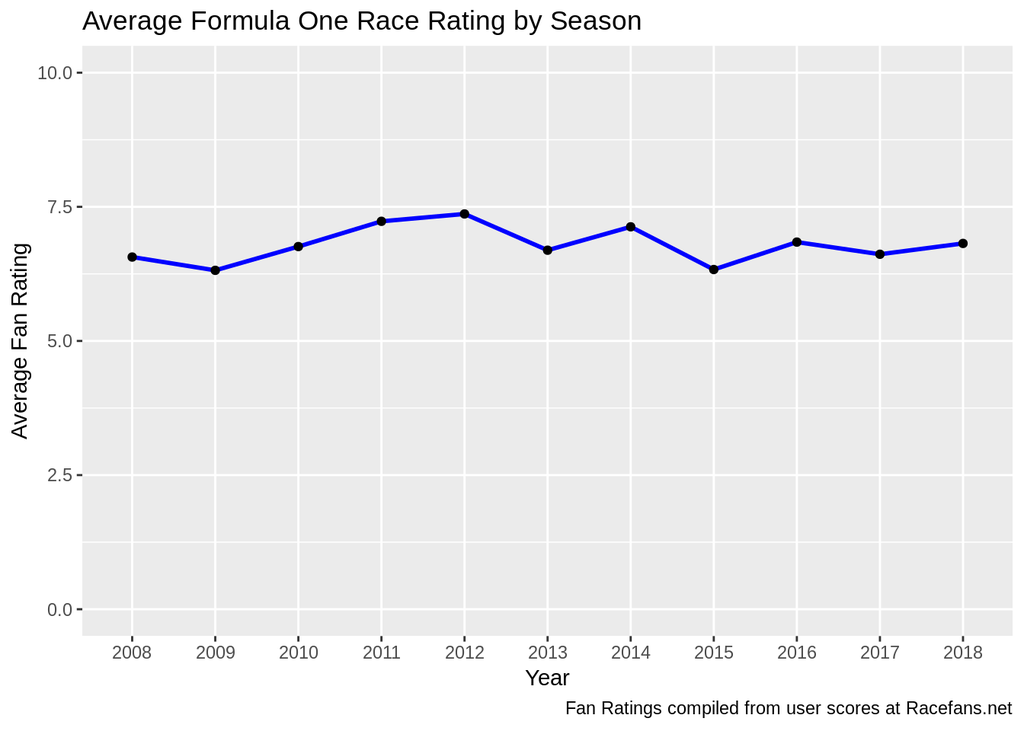

```r
rating_by_season <- fan_ratings %>% group_by(Y) %>% summarize(mean_rating = mean(RATING))

ggplot(rating_by_season, aes(Y,mean_rating)) + geom_line(color="blue", size=1) + geom_point() + scale_x_discrete(name="Year",limits=c(2008:2019)) + scale_y_continuous(name="Average Fan Rating", limits=c(0,10)) + ggtitle("Average Formula One Race Rating by Season") + labs(caption = "Fan Ratings compiled from user scores at Racefans.net")
```

```r
print(rating_by_season)
```

```
## # A tibble: 11 x 2
##        Y mean_rating
##    <int>       <dbl>
##  1  2008        6.56
##  2  2009        6.32
##  3  2010        6.76
##  4  2011        7.23
##  5  2012        7.37
##  6  2013        6.69
##  7  2014        7.13
##  8  2015        6.33
##  9  2016        6.84
## 10  2017        6.62
## 11  2018        6.82
```

The average ratings actually look pretty consistent from year to year.